# Predict The Price Of Books

## Predict The Price Of Books

```python
import os
import numpy as np
import pandas as pd

# Suppressing Warnings
import warnings
warnings.filterwarnings('ignore')

import seaborn as sns
import matplotlib.pyplot as plt
%matplotlib inline

from scipy.stats import skew,kurtosis,zscore

from sklearn.model_selection import train_test_split
from sklearn.preprocessing import PowerTransformer, LabelEncoder
from sklearn.metrics import accuracy_score, mean_squared_error, r2_score

import lightgbm as lgb




from sklearn.feature_extraction.text import CountVectorizer, TfidfVectorizer, HashingVectorizer
from sklearn.pipeline import Pipeline, FeatureUnion
from sklearn.preprocessing import FunctionTransformer
from sklearn.impute import SimpleImputer
from sklearn.metrics import mean_squared_log_error, make_scorer, mean_squared_error
from sklearn.model_selection import train_test_split

from sklearn.linear_model import LinearRegression
from sklearn.naive_bayes import MultinomialNB
from lightgbm import LGBMRegressor
from xgboost import XGBRegressor
from sklearn.model_selection import RandomizedSearchCV
```

### Loading data

```python
train = pd.read_excel(os.path.join('data', 'xlsx', 'Data_Train.xlsx'))
test = pd.read_excel(os.path.join('data', 'xlsx', "Data_Test.xlsx"))
data = pd.concat((train, test))
```

```python
data.head()
```

|  | Title | Author | Edition | Reviews | Ratings | Synopsis | Genre | BookCategory | Price |
| --- | --- | --- | --- | --- | --- | --- | --- | --- | --- |
| 0 | The Prisoner's Gold (The Hunters 3) | Chris Kuzneski | Paperback,– 10 Mar 2016 | 4.0 out of 5 stars | 8 customer reviews | THE HUNTERS return in their third brilliant no... | Action & Adventure (Books) | Action & Adventure | 220.00 |
| 1 | Guru Dutt: A Tragedy in Three Acts | Arun Khopkar | Paperback,– 7 Nov 2012 | 3.9 out of 5 stars | 14 customer reviews | A layered portrait of a troubled genius for wh... | Cinema & Broadcast (Books) | Biographies, Diaries & True Accounts | 202.93 |
| 2 | Leviathan (Penguin Classics) | Thomas Hobbes | Paperback,– 25 Feb 1982 | 4.8 out of 5 stars | 6 customer reviews | "During the time men live without a common Pow... | International Relations | Humour | 299.00 |
| 3 | A Pocket Full of Rye (Miss Marple) | Agatha Christie | Paperback,– 5 Oct 2017 | 4.1 out of 5 stars | 13 customer reviews | A handful of grain is found in the pocket of a... | Contemporary Fiction (Books) | Crime, Thriller & Mystery | 180.00 |
| 4 | LIFE 70 Years of Extraordinary Photography | Editors of Life | Hardcover,– 10 Oct 2006 | 5.0 out of 5 stars | 1 customer review | For seven decades, "Life" has been thrilling t... | Photography Textbooks | Arts, Film & Photography | 965.62 |

### Data Transformations

##### Features:

- Title: The title of the book
- Author: The author(s) of the book.
- Edition: The edition of the book eg (Paperback,– Import, 26 Apr 2018)
- Reviews: The customer reviews about the book
- Ratings: The customer ratings of the book
- Synopsis: The synopsis of the book
- Genre: The genre the book belongs to
- BookCategory: The department the book is usually available at.
- Price: The price of the book (Target variable)

##### No. of Records

```python
len_train, len_test = len(train), len(test)
print("# train:", len_train)
print("# test:", len_test)
```

```
# train: 6237
# test: 1560
```

###### Checking missing values

```python
data.isna().sum()
```

```
Title              0
Author             0
Edition            0
Reviews            0
Ratings            0
Synopsis           0
Genre              0
BookCategory       0
Price           1560
dtype: int64
```

##### Feature Engg: Reviews

Getting integer value

```python
data['Reviews'] = data['Reviews'].apply(lambda x: float(x.split()[0]))
```

```python
# data.head()
```

##### Feature Engg: Ratings

Getting no. of rating (int value)

```python
data['Ratings'] = data['Ratings'].apply(lambda x: (x.split()[0].replace(',',''))).astype(int)
```

```python
data.head()
```

|  | Title | Author | Edition | Reviews | Ratings | Synopsis | Genre | BookCategory | Price |
| --- | --- | --- | --- | --- | --- | --- | --- | --- | --- |
| 0 | The Prisoner's Gold (The Hunters 3) | Chris Kuzneski | Paperback,– 10 Mar 2016 | 4.0 | 8 | THE HUNTERS return in their third brilliant no... | Action & Adventure (Books) | Action & Adventure | 220.00 |
| 1 | Guru Dutt: A Tragedy in Three Acts | Arun Khopkar | Paperback,– 7 Nov 2012 | 3.9 | 14 | A layered portrait of a troubled genius for wh... | Cinema & Broadcast (Books) | Biographies, Diaries & True Accounts | 202.93 |
| 2 | Leviathan (Penguin Classics) | Thomas Hobbes | Paperback,– 25 Feb 1982 | 4.8 | 6 | "During the time men live without a common Pow... | International Relations | Humour | 299.00 |
| 3 | A Pocket Full of Rye (Miss Marple) | Agatha Christie | Paperback,– 5 Oct 2017 | 4.1 | 13 | A handful of grain is found in the pocket of a... | Contemporary Fiction (Books) | Crime, Thriller & Mystery | 180.00 |
| 4 | LIFE 70 Years of Extraordinary Photography | Editors of Life | Hardcover,– 10 Oct 2006 | 5.0 | 1 | For seven decades, "Life" has been thrilling t... | Photography Textbooks | Arts, Film & Photography | 965.62 |

##### Feature Engg: Transforming following columns to lower

- Title
- Author
- Edition
- Synopsis
- Genre
- BookCategory

```python
for col in ['Title','Author','Edition','Synopsis','Genre','BookCategory']:
    data[col] = data[col].str.lower()
```

```python
data.head()
```

|  | Title | Author | Edition | Reviews | Ratings | Synopsis | Genre | BookCategory | Price |
| --- | --- | --- | --- | --- | --- | --- | --- | --- | --- |
| 0 | the prisoner's gold (the hunters 3) | chris kuzneski | paperback,– 10 mar 2016 | 4.0 | 8 | the hunters return in their third brilliant no... | action & adventure (books) | action & adventure | 220.00 |
| 1 | guru dutt: a tragedy in three acts | arun khopkar | paperback,– 7 nov 2012 | 3.9 | 14 | a layered portrait of a troubled genius for wh... | cinema & broadcast (books) | biographies, diaries & true accounts | 202.93 |
| 2 | leviathan (penguin classics) | thomas hobbes | paperback,– 25 feb 1982 | 4.8 | 6 | "during the time men live without a common pow... | international relations | humour | 299.00 |
| 3 | a pocket full of rye (miss marple) | agatha christie | paperback,– 5 oct 2017 | 4.1 | 13 | a handful of grain is found in the pocket of a... | contemporary fiction (books) | crime, thriller & mystery | 180.00 |
| 4 | life 70 years of extraordinary photography | editors of life | hardcover,– 10 oct 2006 | 5.0 | 1 | for seven decades, "life" has been thrilling t... | photography textbooks | arts, film & photography | 965.62 |

##### Feature Engg: Genre

Cleanup and removing `(books)`, `Textbooks`

```python
data['Genre'] = data['Genre'].apply(lambda x: x.strip('(books)').strip('Textbooks'))
```

```python
# data.head()
```

##### Feature Engg: Extracting `Edition_Year` of publish from the `Edition` column

```python
data['Edition_Year'] = data['Edition'].apply(lambda x: x.split()[-1] if x.split()[-1].isdigit() else 'na')
```

```python
# data.head()
```

##### Feature Engg: Extracting `Binding` of publish from the `Edition` column

```python
data['Binding'] = data['Edition'].apply(lambda x: np.where('paperback' in x, 1, 0))
```

```python
# data.head()
```

##### Feature Engg: Merging `Synopsis` and `Title`

```python
data['Synopsis'] = data['Synopsis'] + " " + data['Title']
```

```python
data.head()
```

|  | Title | Author | Edition | Reviews | Ratings | Synopsis | Genre | BookCategory | Price | Edition_Year | Binding |
| --- | --- | --- | --- | --- | --- | --- | --- | --- | --- | --- | --- |
| 0 | the prisoner's gold (the hunters 3) | chris kuzneski | paperback,– 10 mar 2016 | 4.0 | 8 | the hunters return in their third brilliant no... | action & adventure | action & adventure | 220.00 | 2016 | 1 |
| 1 | guru dutt: a tragedy in three acts | arun khopkar | paperback,– 7 nov 2012 | 3.9 | 14 | a layered portrait of a troubled genius for wh... | cinema & broadcast | biographies, diaries & true accounts | 202.93 | 2012 | 1 |
| 2 | leviathan (penguin classics) | thomas hobbes | paperback,– 25 feb 1982 | 4.8 | 6 | "during the time men live without a common pow... | international relation | humour | 299.00 | 1982 | 1 |
| 3 | a pocket full of rye (miss marple) | agatha christie | paperback,– 5 oct 2017 | 4.1 | 13 | a handful of grain is found in the pocket of a... | contemporary fiction | crime, thriller & mystery | 180.00 | 2017 | 1 |
| 4 | life 70 years of extraordinary photography | editors of life | hardcover,– 10 oct 2006 | 5.0 | 1 | for seven decades, "life" has been thrilling t... | photography | arts, film & photography | 965.62 | 2006 | 0 |

### Data Analysis

##### BookCategory vs Price

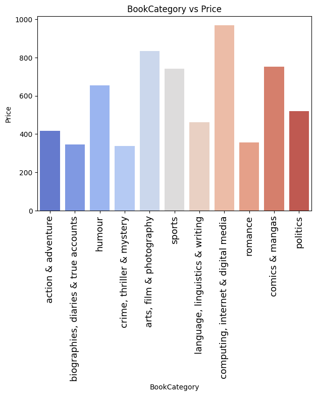

```python
plt.figure(figsize=(7, 5))
sns.barplot(data = data, x = 'BookCategory', y = 'Price',
           palette = 'coolwarm',
           ci = None)
plt.xticks(size = 13, rotation = 90);
plt.title('BookCategory vs Price');
```

- `Computing,internet & digital media` Category has higher price value
- `biographies, diaries & trie accounts`, `crime, thriller & mystery`, `romance` Categories have low price value

##### Data Distribution - Price, Reviews, Ratings

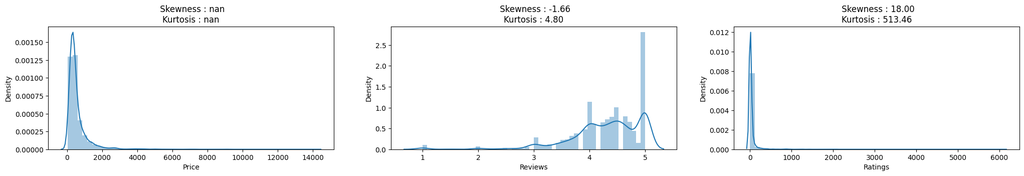

```python
plt.figure(figsize = (25, 7))
for i, col in enumerate(['Price','Reviews','Ratings']):
    plt.subplot(2, 3, i + 1)
    sns.distplot(data[col]).set_title(" Skewness : %.2f\nKurtosis : %.2f"%(skew(data[col]), kurtosis(data[col])))
plt.show()
```

- The distribution for each variable is not very clear. Also, we have few outliers in the data.
- The `skewness` and `kurtosis` is showing `nan` due to missing values in column `Price` in test dataset

##### Pairplot among Price, Reviews, Ratings

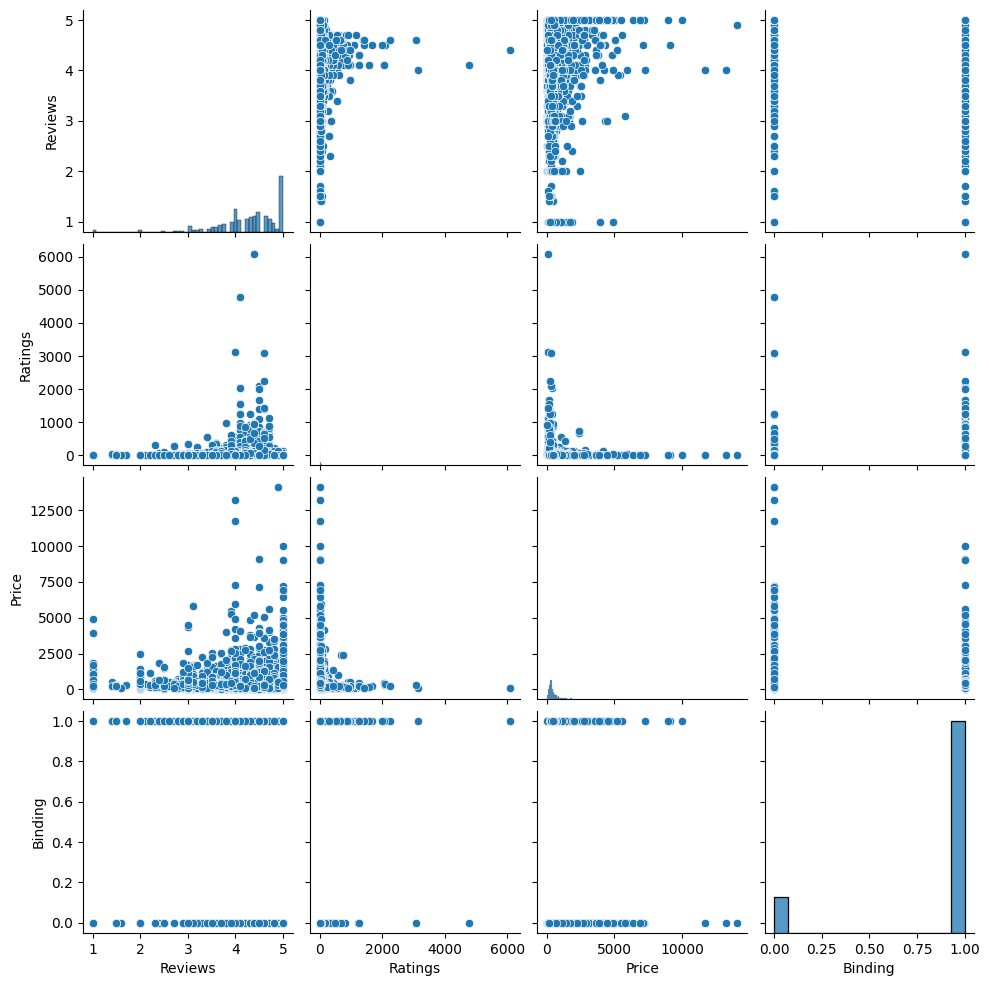

```python
sns.pairplot(data)
plt.show()
```

- These pair plots do not enhance the correlation between variables.
- Applying Power Transformation to make data more Gaussian-like and standardize

##### Applying PowerTransformation

```python
power = PowerTransformer()
data[['Reviews']] = power.fit_transform(data[['Reviews']])
data[['Ratings']] = power.fit_transform(data[['Ratings']])
data[['Price']] = power.fit_transform(data[['Price']])
```

##### Data Distribution - Price, Reviews, Ratings 2

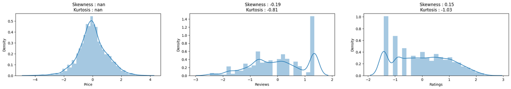

```python
plt.figure(figsize = (25, 7))
for i, col in enumerate(['Price','Reviews','Ratings']):
    plt.subplot(2, 3, i + 1)
    sns.distplot(data[col]).set_title(" Skewness : %.2f\nKurtosis : %.2f"%(skew(data[col]), kurtosis(data[col])))
plt.show()
```

##### Pairplot among Price, Reviews, Ratings 2

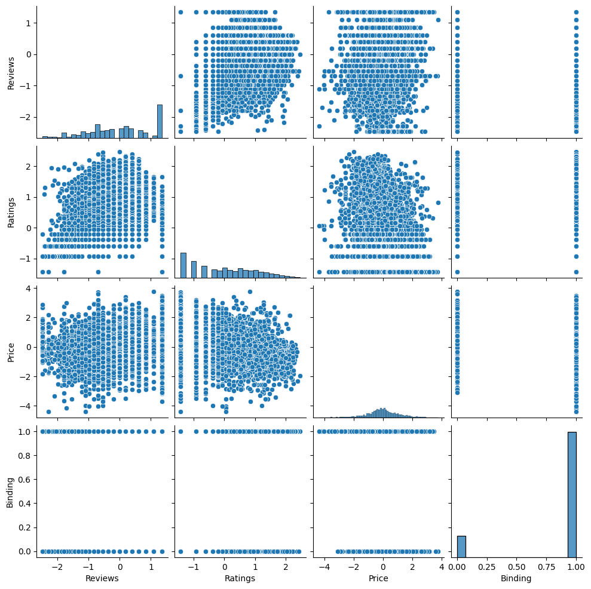

```python
sns.pairplot(data)
plt.show()
```

##### Dropping columns

```python
data = data.drop(columns=['Edition','Title', 'Synopsis'])
# data
```

##### Getting unique counts

```python
for col in ['Author', 'Genre', 'BookCategory', 'Edition_Year']:
    print("%s: %d"%(col, len(data[col].unique())))
print();print("# records: %d"%(len(data)))
```

```
Author: 4359
Genre: 359
BookCategory: 11
Edition_Year: 59

# records: 7797
```

Given number of records, we can do LabelEncoding for:

- Author
- Genre
- BookCategory
- Edition_Year

We might try OneHotEncoding for BookCategory.

##### Applying LabelEncoder on Author, Genre, BookCategory, Edition_Year

```python
data['Author'] = LabelEncoder().fit_transform(data['Author'])
data['Genre'] = LabelEncoder().fit_transform(data['Genre'])
data['BookCategory'] = LabelEncoder().fit_transform(data['BookCategory'])
data['Edition_Year'] = LabelEncoder().fit_transform(data['Edition_Year'])
```

```python
data.info()
data.head()
```

```
<class 'pandas.core.frame.DataFrame'>
Int64Index: 7797 entries, 0 to 1559
Data columns (total 8 columns):
 #   Column        Non-Null Count  Dtype
---  ------        --------------  -----
 0   Author        7797 non-null   int32
 1   Reviews       7797 non-null   float64
 2   Ratings       7797 non-null   float64
 3   Genre         7797 non-null   int32
 4   BookCategory  7797 non-null   int32
 5   Price         6237 non-null   float64
 6   Edition_Year  7797 non-null   int32
 7   Binding       7797 non-null   int64
dtypes: float64(3), int32(4), int64(1)
memory usage: 684.4 KB
```

|  | Author | Reviews | Ratings | Genre | BookCategory | Price | Edition_Year | Binding |
| --- | --- | --- | --- | --- | --- | --- | --- | --- |
| 0 | 746 | -0.692247 | 0.151697 | 3 | 0 | -0.769233 | 54 | 1 |
| 1 | 368 | -0.837992 | 0.540169 | 80 | 2 | -0.885866 | 50 | 1 |
| 2 | 4035 | 0.846409 | -0.063034 | 203 | 6 | -0.337797 | 20 | 1 |
| 3 | 75 | -0.537118 | 0.491200 | 105 | 5 | -1.061408 | 55 | 1 |
| 4 | 1132 | 1.350579 | -1.420206 | 284 | 1 | 1.150774 | 44 | 0 |

### Preparing data for model training

```python
train, test = data[:len_train], data[len_train:]
y_train = train.pop('Price')
test.pop('Price');

X_train = train
X_test = test
```

### `LGBM Regressor`: Model parameters for gridsearch

LightGBM is a gradient boosting framework that uses tree based learning algorithms. It is designed to be distributed and efficient with the following advantages:

- Faster training speed and higher efficiency.
- Lower memory usage.
- Better accuracy.
- Support of parallel and GPU learning.
- Capable of handling large-scale data.
- LightGBM can use categorical features directly (without one-hot encoding). hows about 8x speed-up compared with one-hot encoding.

```python
# FT for datasets
data_ft = FunctionTransformer(lambda x: x[['Author', 'Reviews', 'Ratings', 'Genre', 'BookCategory', 'Edition_Year', 'Binding']], validate = False)
pipeline_ft = Pipeline([('selector', data_ft),])
```

```python
params = {
    'clf__n_estimators' : [100, 200],
    #'clf__max_depth' : [3,4,5,6,7],
    'clf__learning_rate': [0.01, 0.1, 0.01],
    'clf__reg_lambda': list(np.arange(0.1, 0.9, 0.1)),
    #'clf__colsample_bytree' : list(np.arange(0.1,0.8,0.1)),
    'clf__importance_type': ['gain', 'weight', 'cover', 'total_gain', 'total_cover'],
    #'clf__booster': ['gbtree', 'gblinear', 'dart']
}
```

```python
pipeline = Pipeline([('numeric', pipeline_ft), ('clf', LGBMRegressor(verbosity = 1, objective = 'regression'))])
```

##### Custom Storing Method

```python
def get_score(y_val, y_pred):
    return np.sqrt(mean_squared_log_error(y_pred, y_val))

criteria = make_scorer(get_score, greater_is_better = False)
grid = RandomizedSearchCV(pipeline, param_distributions = params, n_iter = 15, cv = 5, scoring = criteria, verbose = 0);
grid.fit(X_train, y_train);
```

```python
print(grid.best_params_)
print('Best Score: ', grid.best_score_)
```

```
{'clf__reg_lambda': 0.2, 'clf__n_estimators': 200, 'clf__learning_rate': 0.01, 'clf__importance_type': 'total_cover'}
Best Score:  nan
```

##### Make predictions on train data

```python
y_pred_train = grid.predict(X_train)
print('Mean Squared Error: ', mean_squared_error(y_pred_train, y_train))

print('Validation set score: ', 1 - np.sqrt(np.square(np.log10(y_pred_train +1) - np.log10(y_train +1)).mean()))
```

```
Mean Squared Error:  0.6359827981637612
Validation set score:  0.6681413835462638
```

```python
OUTPUT = pd.DataFrame(grid.predict(test), columns=['Price'])

OUTPUT.to_csv('submissions.csv',index=None)
```